# Moritz P. Schwarz — redesign mockup

Design preview · Homepage and Publications · Live website unchanged

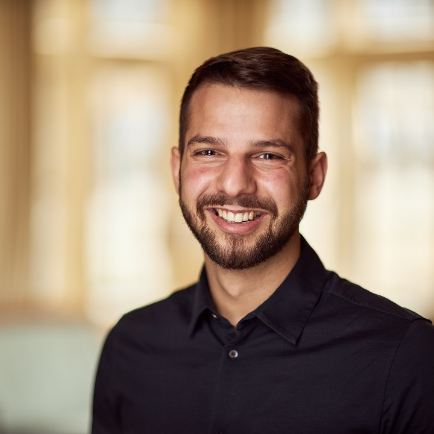

Dr Moritz P. Schwarz

Applied Economist  
Econometrics & Forecasting  
Climate & Energy Policy

Between Berlin, Vienna  
and Oxford

- Email ↗
- [Google Scholar ↗](https://scholar.google.com/citations?user=-j4hwZAAAAAJ)

Applied economics · Econometrics · Climate policy

# Moritz P. Schwarz

I am an applied economist and econometrician working on causal identification, empirical macro-modelling, and environmental and climate policy.

Explore publications Job market paper Download CV

I currently hold an [Einstein International Postdoctoral Fellowship](https://www.einsteinfoundation.de/en/fellows-projects/einstein-fellows-professors/einstein-international-postdoctoral-fellows/moritz-p-schwarz) financed by the Einstein Foundation in Berlin, and **I am on the 2026/2027 job market**.

I obtained my DPhil (PhD) in Economics from the University of Oxford working with the [Climate Econometrics](https://www.climateeconometrics.org/) group at Nuffield College, and I am based at the Faculty of Economics and Management at TU Berlin and at the Potsdam Institute for Climate Impact Research (PIK). I remain affiliated with the [Institute for New Economic Thinking at the Oxford Martin School](https://www.inet.ox.ac.uk/) and the [Smith School of Enterprise and the Environment](https://www.smithschool.ox.ac.uk/).

## Research

My research combines **econometric method development** with **empirical macroeconomics** and **policy evaluation**. It is organised around three strands:

1. **Causal identification and reverse-causal inference**  
   I develop tools to detect unknown interventions and regime shifts as structural breaks in panel and time-series models, linking break detection to modern causal-inference frameworks. These methods underpin applications such as identifying which national climate and energy policies have actually reduced emissions (e.g. work published in *Science* and *Nature Energy*) and improving robustness in climate-impact estimation (e.g. *Journal of Econometrics*).
2. **Empirical macro-modelling and forecasting under structural change**  
   I lead the development of the **Open-Source Empirical Macro (OSEM)** model, a multi-equation empirical framework that jointly forecasts macroeconomic, energy, and environmental variables. OSEM combines automatic model selection, break detection, and error-correction techniques and is used by Austria’s Ministry of Finance and the UK Department for Energy Security and Net Zero. This work complements structural/DSGE and CGE-type models and speaks to macro-fiscal, financial-stability, and transition questions.
3. **Applications in climate, energy, and just transitions**  
   I apply these methods to quantify the real-world impacts of climate change and climate policy, including the effectiveness of national policy packages, the macroeconomic consequences of warming and extremes, and the labour-market and distributional dimensions of the clean energy transition. This includes work on just transition, state-owned enterprises, and the interaction between fiscal policy and climate objectives.

Across these strands, a common theme is **empirical transparency in macroeconomic and environmental policy analysis**: using open, reproducible tools to understand which policies work, how shocks propagate through the economy, and how to design more resilient macroeconomic and climate strategies.

## Software

I contribute to several open-source R packages that implement the methods I use in my research:

- [{gets}](https://cran.r-project.org/web/packages/gets/index.html): general-to-specific modelling, indicator saturation, structural breaks, and automated model selection.
- {getspanel}: extension of gets-type methods to panel data and causal-inference settings (including reverse-causal identification).
- {osem}: implementation of the Open-Source Empirical Macro model for joint macro–energy–emissions forecasting and scenario analysis.

These packages are widely used by researchers and policy institutions and form the backbone of my empirical work.

## Background and affiliations

During my DPhil studies at Oxford (Brasenose College), I worked closely with the Climate Econometrics project at Nuffield College. My doctoral research was supervised by Prof Sir David F. Hendry and Prof Cameron Hepburn and was supported by the Clarendon Fund.

In addition to academic work, I have served as a Senior Climate Economist at Austria’s Ministry of Finance, contributing to macro-fiscal projections, green budgeting, and EU-level climate and energy policy processes (including the design of carbon pricing and the Carbon Border Adjustment Mechanism).

## Selected Research:

### **Science:** Identifying successful climate policies

As part of an international research team, we have published the first global assessment of climate policies in the four most critical emission sectors in the journal *Science*.

We unveiled the first comprehensive global evaluation of 1,500 climate policy measures from 41 countries across six continents. We identified ‘emission breaks’ and assigned them policy interventions, pinpointing where policies may have had a large impact. The break detection methodology, called indicator saturation estimation, developed at Climate Econometrics, allows break indicators for all possible dates to be examined objectively using a variant of machine learning. This unprecedented study provides a detailed impact analysis of the wide range of climate policy measures implemented across the planet over the last two decades.

We have identified 63 cases of successful climate policies with large emission reductions with the key characteristic of these successful cases being the inclusion of tax and price incentives in well-designed policy mixes. Our study also shows that if more countries relied on policies like these ones, the remaining emissions gap for 2030 could be closed by as much as 26% to 41%. The identified successful policies have led to an average emission reduction of 19 percent. In total, the 63 policy interventions reduced emissions between 0.6 and 1.8 billion tonnes of CO2.

For more detail on the identified policies, check out our [Climate Policy Exporer](http://climate-policy-explorer.pik-potsdam.de/) where you can dive deeper into our results and findings.

[Stechemesser A., Koch, N., Mark E., Klösel P., Nachtigall, D., Pretis, F., Ritter N., Schwarz M., et al. (2024). **Climate policies that achieved major emission reductions: Global evidence from two decades.** *Science*.](https://www.science.org/doi/10.1126/science.adl6547)

[[Data and code](https://zenodo.org/records/12773811)][[Interactive web dashboard](http://climate-policy-explorer.pik-potsdam.de/)]

**Media**: [[New York Times](https://www.nytimes.com/2024/08/22/climate/climate-policies.html)][[Financial Times](https://www.ft.com/content/8095afce-13eb-4b94-8ea7-1fd1a90bd99b)][[Wall Street Journal](https://www.wsj.com/science/environment/climate-change-policies-emissions-ai-research-a02b3f59)][[Washington Post](https://www.washingtonpost.com/politics/2024/08/22/climate-change-price-hike-policies-emissions/c6e64876-60b0-11ef-ae22-cef4d8785d67_story.html)][[NewScientist](https://www.newscientist.com/article/2445014-most-climate-policies-do-little-to-prevent-climate-change/)][[Associated Press](https://apnews.com/article/climate-change-price-hike-policies-emissions-1d211ff66f7ab768a69466b9af281c79)][[CNN](https://amp.cnn.com/cnn/2024/08/22/climate/climate-policies-review-coal-cars)][[CBC](https://www.cbc.ca/news/science/effective-climate-policies-1.7301998)][[The Economist](https://www.economist.com/science-and-technology/2024/10/02/why-its-so-hard-to-tell-which-climate-policies-actually-work)][[The Times](https://www.thetimes.com/business-money/economics/article/harris-and-trump-are-too-busy-scrapping-old-promises-to-mention-what-matters-5whl8ql5d)][[El Mundo](https://www.elmundo.es/ciencia-y-salud/medio-ambiente/2024/08/22/66c75f4a21efa0c2478b456f.html)][[Le Monde](https://www.lemonde.fr/planete/article/2024/09/08/climat-seule-la-combinaison-de-plusieurs-mesures-est-efficace-pour-faire-baisser-les-emissions-de-gaz-a-effet-de-serre_6307004_3244.html)][[L’Express](https://www.lexpress.fr/environnement/pour-reduire-les-emissions-de-co2-vaut-il-mieux-agiter-la-carotte-ou-le-baton-QLJGPZJP2VBKBK7E5X3OCZ4NTI/)][[France Culture](https://www.radiofrance.fr/franceculture/podcasts/avec-sciences/climat-une-infime-partie-des-politiques-ont-un-reel-impact-4190342)][[ORF](https://science.orf.at/stories/3226410/)][[Der Standard](https://www.derstandard.at/story/3000000233384/von-1500-massnahmen-fuer-weniger-emissionen-waren-nur-63-sehr-erfolgreich)][[Spiegel](https://www.spiegel.de/wissenschaft/klimaneutralitaet-bis-2050-studie-zeigt-welche-massnahmen-besonders-wirksam-sind-a-6d162367-f1ff-427a-b4a0-34d7827dea4c)][[Zeit](https://www.zeit.de/wissen/umwelt/2024-08/klimaschtzpolitik-co2-ausstoss-massnahmen-nachhaltigkeit-mobilitaet)][[FAZ](https://www.faz.net/aktuell/wirtschaft/klima-nachhaltigkeit/klimapolitik-verbote-allein-bewirken-wenig-19938361.html)][[SZ](https://www.sueddeutsche.de/wissen/politik-klimaschutz-massnahmen-auswertung-lux.NDXE6KZQpvGs37KU23gUyx?reduced=true)][[zdf](https://www.zdf.de/nachrichten/politik/deutschland/klimawandel-massnahmen-klimapolitik-100.html)][[Deutschlandfunk](https://www.deutschlandfunk.de/gute-klimapolitik-welche-massnahmen-die-emissionen-wirklich-senken-dlf-7cea458e-100.html)][[Nature News](https://www.nature.com/articles/d41586-024-02717-7)]

### **Energy Policy:** Labour Market Impacts of Coal Mine Closures

We have recently published a paper in *Energy Policy* that considers the dynamics of the US labour market that are associated with coal mines closing. The paper finds that coal mine closures raise US county unemployment rates with spatial ripple effects and that Just Transition interventions should tailor to local conditions to alleviate impacts.

[Mark, E., Rafaty, R. and Schwarz, M. (2024). **Spatio-temporal dynamics of structural unemployment in declining coal mining regions and potentialities of the ‘just transition’**. *Energy Policy*.](https://www.sciencedirect.com/science/article/pii/S0301421524003586)

You can find my full publication list [here](https://moritzpschwarz.github.io/publications/).